# Medical Appointments No-Show

## by Emefiele-konyeri Awinrin

## Investigation Overview

In this investigation, i want to find out some of the factor that have might cause patients to miss their appointments. Patient no-shows are long-standing issues affecting resource utilization and posing risks to the quality of healthcare services. They also lead to loss of anticipated revenue, particularly in services where resources are expensive and in great demand.

## Dataset Overview

The Medical Appointments No-Show data consists of 110527 appointments and 14 features('PatientId', 'AppointmentID', 'Gender', 'ScheduledDay','AppointmentDay', 'Age', 'Neighbourhood', 'Scholarship', 'Hipertension','Diabetes', 'Alcoholism', 'Handcap', 'SMS_received', 'No-show'), after data cleaning the dataset was transformed to 110475 observations and 20 features(additional features: 'Scheduleddate', 'Appointmentday', 'Appointmentdate', 'AwaitingDays', 'Awaitingtime', 'Age_group').

## Distribution Of Age

This distribution is bimodal with kids the age of 5 or less having the highest number of appointments followed by adults with the age 50 to 55

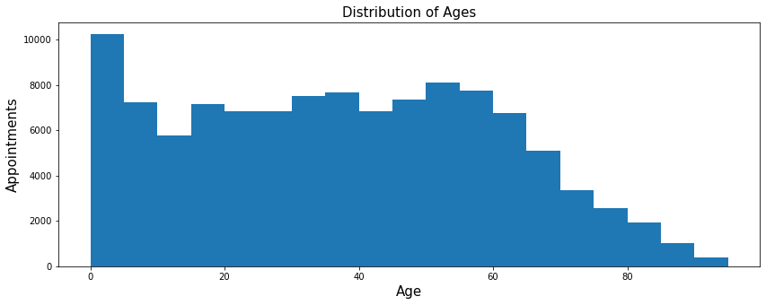

## Proportion of No-Show Appointments

About 20% of appointments were missed which is quite a large number.Patients' failure to attend medical appointments saps resources and waste every business's most valued asset, "time.". When patients miss their medical appointment, the implications are detrimental to your practice and the patient.

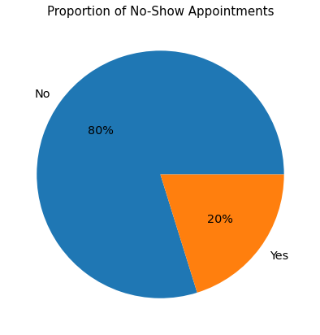

## Distribution of Age Groups and No-Show Rate

So out of the 20% of No-Show appointments in the dataset Adults had about 11.52% No-Show rate which is more than the total No-Show rate of the other age groups

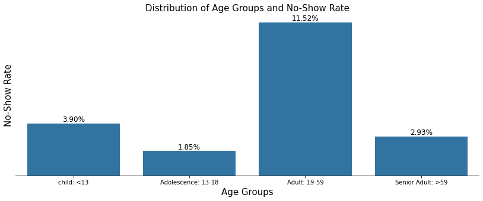

## Distribution of Health conditions and No-Show rate

Hypersion patients have the highest No-Show rate of all the Health related conditions with a No-Show rate of 3.41% and Handicap seeming to have the least No-Show rate

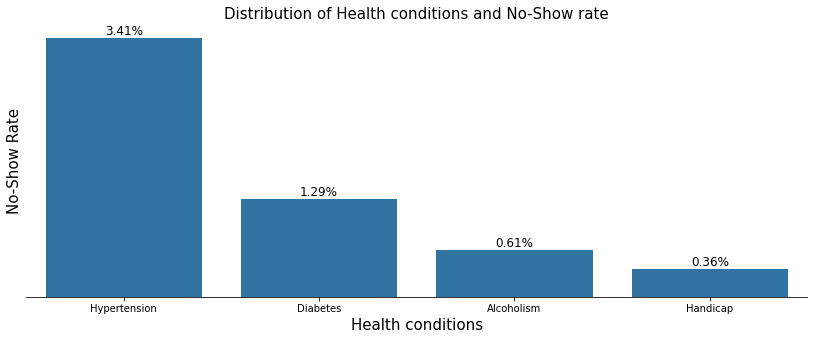

## Distribution of Types of conditions and No-Show rate

Even after receiving text messages, patients on a scholarship have a No-Show rate which is far less than half the No-Show rate of patients with SMS received

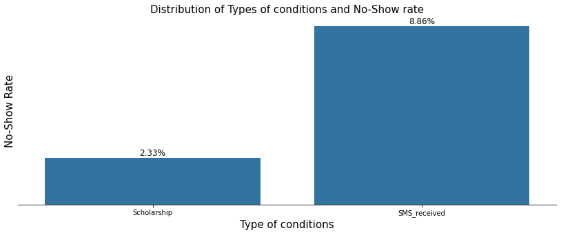

## Distribution of AwaitingDays and No-Show rate

Patients that have an awaiting time of a month have the highest No-Show rate, patients with an awaiting time of the same day have a low No-Show rate compared to awaiting time of a month

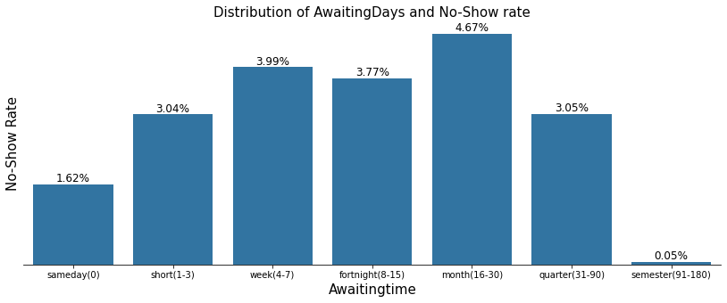

## Distribution of Appointmentday and No-Show rate

From assessment the No-Show rate is higher before midweek and lower after midweek maybe due to the intensity of work which tends to be at the beginning of the week

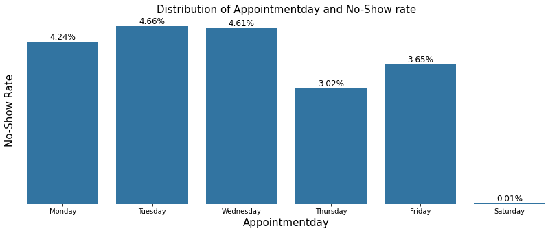

## Analysis Overview

After rigorously going through the data i was able to ask some questions that could help gain insight on the statistics of the dataset:

### What is total number of Appointments and No show compared between the gender of the patient and the number of awaiting days ?

Monthly waiting time has the most number of appointments and highest No Show rate in the chart, with female patients having the most number of appointments in all awaiting times. This analysis enlightens the fact that shorter waiting times would be more appealing to the patients

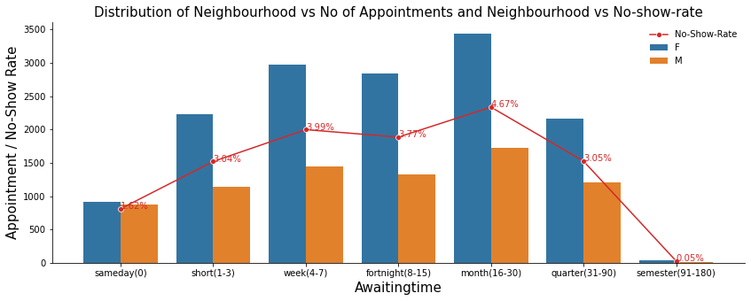

### What is total number of Appointments and No show compared between the gender and age of the patient ?

Adults(19-59) have the highest number of appointments and highest no-show-rate while Adolescence have the least number of appointments and least no-show-rate

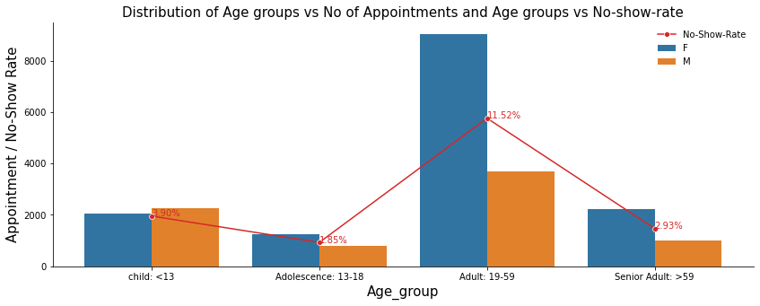

### Which day of the week has the highest number of appointments and no show rate ?

From the bar plot graph above, the No-Show rate and No of Appointments are higher before midweek and lower after midweek. The No-Show rate and No of Appointments seems to be directly proportional(the higher the appointments the higher the no show rate). Tuesday has the highest number of appointments and no show rate, this tells us patients are like if their appointments where scheduled after midweek when their work for the week has become less intensed

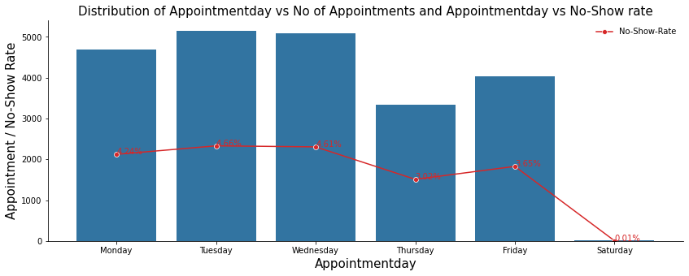

### Which Neighbourhood has the highest number of no show appointments and no show rate ?

The graph tells us that the neighbourhood JARDIM CAMBURI has the highest number of no show appointments and no show rate while AEROPORTO has the lowest number of no show appointments and no show rate

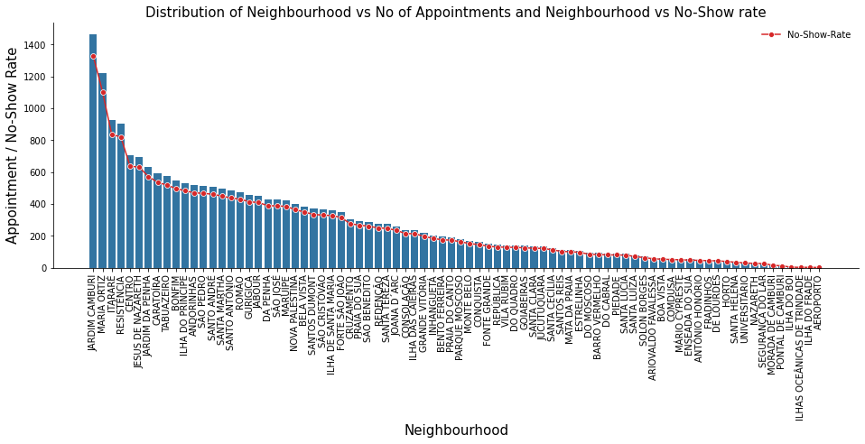

### Which attribute had the highest no show rate across waiting days ?

Patients that received SMS had the highest no show rates after a week maybe because 1 text message is not enough to remind them of their appointment,before a week they had low no show rates.

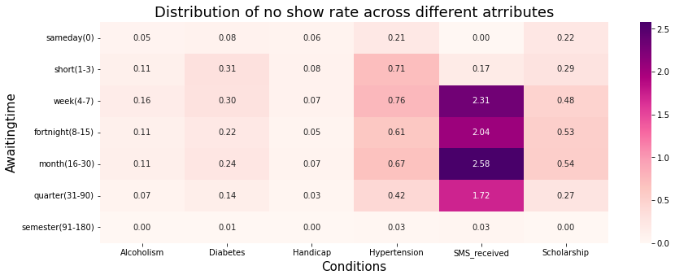